# HW12 - Mixed Models

Jamie Ash

11/17/2021

This assignment will use some data from the attached paper by Cabral et al. The authors looked at biogeographic and environmental variables that predict the species richness of vascular plants on oceanic islands. Asking what predicts species richness on oceanic islands is a classic question; the more novel angle of the authors was to focus on the fact that islands often come in archipelagos, and there are likely important processes that operate at the archipelago scale, in addition to the island scale. We’ll use this idea as an example for using mixed models.

The authors compiled a database of many variables, which I’ve simplified for this exercise. The file ‘cabral_island_data.csv’ contains these variables measured at the island scale: species richness (‘Species’), island area (km2), maximum elevation (meters), and mean temperature. The file ‘cabral_arch_data.csv’ contains these variables measured at the archipelago scale: age of the oldset island (millions of years), number of islands in the archipelago, distance of the archipelago from the nearest continent (km).

All of these predictors could be important for species diversity on islands, and the point of the analysis is to figure out which ones actually have support, using a comparative approach. We will focus on island-level richness (the authors also look at between-island beta diversity and whole-archipelago gamma diversity). Island area is a proxy for environmental heterogeneity, and also affects the target size for colonists; maximum elevation is also a proxy for heterogeneity; mean temperature may or may not be important, depending on how you think the latitudinal diversity gradient arises; age of the oldest island determines time for colonization and time for diversification; number of islands in the archipelago could determine the total target size for colonization; and distance to the mainland will affect the supply of propagules.

```r
# reading data from given csv: Archepelegio Data
arch             <- read.csv(paste("..\\data\\", "cabral_arch_data.csv", sep = ""))
colnames(arch)   <- c("row", "archipelago", "island", "distance", "age")
arch$archipelago <- as.factor(arch$archipelago)
arch$island      <- as.numeric(arch$island)
arch             <- arch[, !names(arch) == "row"]


# reading data from given csv: Island data
isle             <- read.csv(paste("..\\data\\", "cabral_island_data.csv", sep = ""))
colnames(isle)   <- c("row", "archipelago", "species", "area", "elev", "temp")
isle$archipelago <- as.factor(isle$archipelago)
isle$elev        <- as.numeric(isle$elev)
isle             <- isle[, !names(isle) == "row"]

# Merging the two data frames
daislands <- merge(arch, isle, by = c("archipelago"))
```

# 1 Only archipelago

To start, let’s consider that the data are naturally organized into groups(archipelagoes), and we should account for this structure (non-independence) in the model. In addition, some of the predictors are defined at the scale of the archipelago, which means we need an archipelago random effect in order to not pseudoreplicate when testing those predictors. Make a model with species richness as the response, and with a random effect for Archipelago. Species richness could be modeled as discrete count data (e.g., a negative binomial distribution), but we’ll cover GLMMs later; for now you can use log(Richness+1) to get a pretty normal looking response. What proportion of the variation in species richness occurs at the archipelago scale, and what proportion occurs within archipelagoes? Which archipelagoes are particularly diverse, and which are depauperate?

**Answer:** The variation in species richness at the archipelego scale is 0.64 (sd = 0.80), while the variation in species richness at the island scale is 0.82 (sd = 0.90). So the proportion of species richness atributed to the archipelego scale is 0.44, and the proportion of species richness variation within the archipelego scale is 0.56. I found that the Balearic Islands and the Canaries are particularly diverse, while the Phoenix Islands and the Iles Corzet are particularly depaurerate.

## 1.1 Model Summary

```r
rand.mod = lmer(log(species+1) ~ 1 + (1|archipelago), data = daislands)
summary(rand.mod)
```

```
## Linear mixed model fit by REML ['lmerMod']
## Formula: log(species + 1) ~ 1 + (1 | archipelago)
##    Data: daislands
##
## REML criterion at convergence: 501.2
##
## Scaled residuals:
##     Min      1Q  Median      3Q     Max
## -5.1507 -0.5357  0.0796  0.5790  1.9455
##
## Random effects:
##  Groups      Name        Variance Std.Dev.
##  archipelago (Intercept) 0.6408   0.8005
##  Residual                0.8243   0.9079
## Number of obs: 174, groups:  archipelago, 23
##
## Fixed effects:
##             Estimate Std. Error t value
## (Intercept)   4.7685     0.1865   25.57
```

```r
arches <- ranef(rand.mod)[[1]]
arches <- data.frame(row.names(arches), arches)
row.names(arches) <- NULL
colnames(arches) <- c("archipelego", "intercept")

# Least anbd greates species richness
arches[order(arches[,2]), ][1:2, ]
```

```
##        archipelego intercept
## 18 Phoenix Islands -1.353685
## 10     Iles Crozet -1.166046
```

```r
arches[order(arches[,2]), ][(nrow(arches)-1):nrow(arches), ]
```

```
##        archipelego intercept
## 3 Balearic Islands  1.181832
## 4         Canaries  1.459040
```

## 1.2 Plotted Effects

```r
plot_model(rand.mod, type = "re")
plot_model(rand.mod, type = 'diag')[[2]]
```

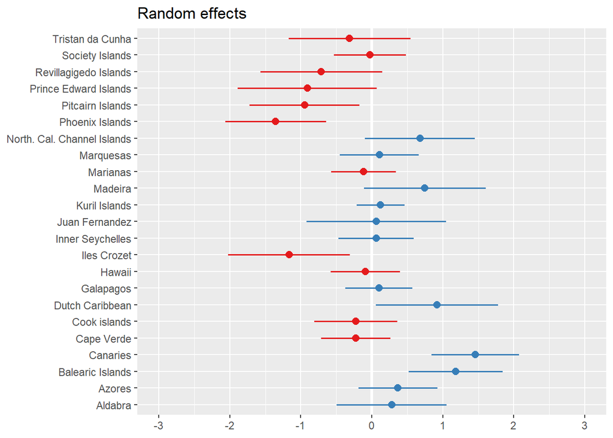

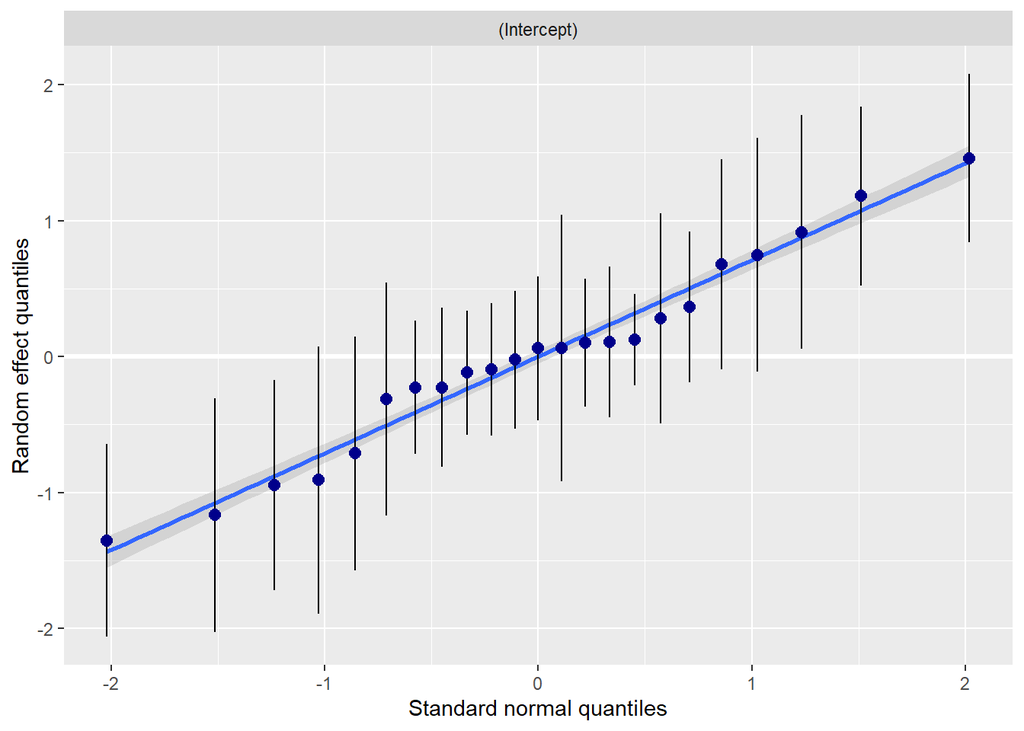

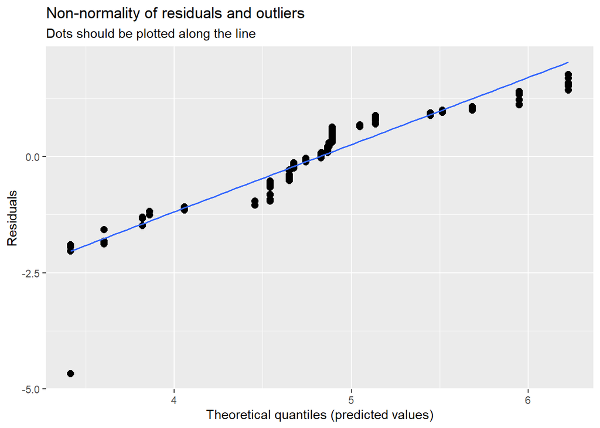

```r
plot_model(rand.mod, type = 'diag')[[1]]
```

# 2 Checking predictors

Now let’s think about the six predictors. Make some exploratory plots of the effect of each variable on richness, plotted at the appropriate scale. You’ll need to merge the datasets. Think about which predictors might need to be transformed for use in a linear model.

```r
#transforming the parameters
daislands$area     <- log(daislands$area + 1)
daislands$elev     <- log(daislands$elev + 1)
daislands$distance <- log(daislands$distance + 1)
#transforming the parameters
#daislands$area <- sqrt(daislands$area)
#daislands$elev <- sqrt(daislands$elev)
```

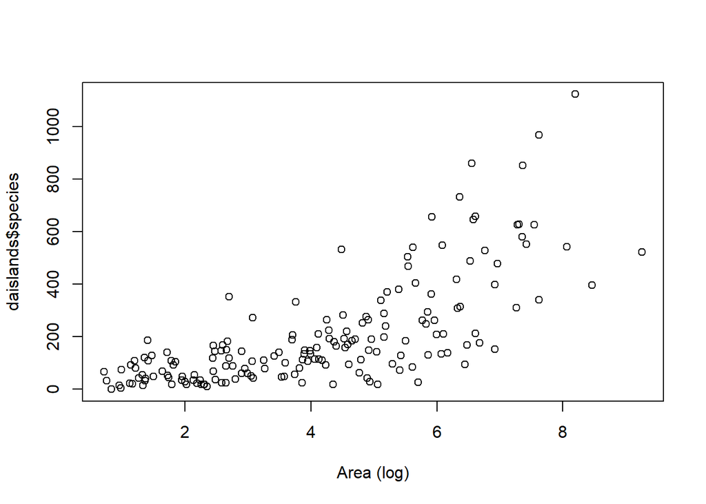

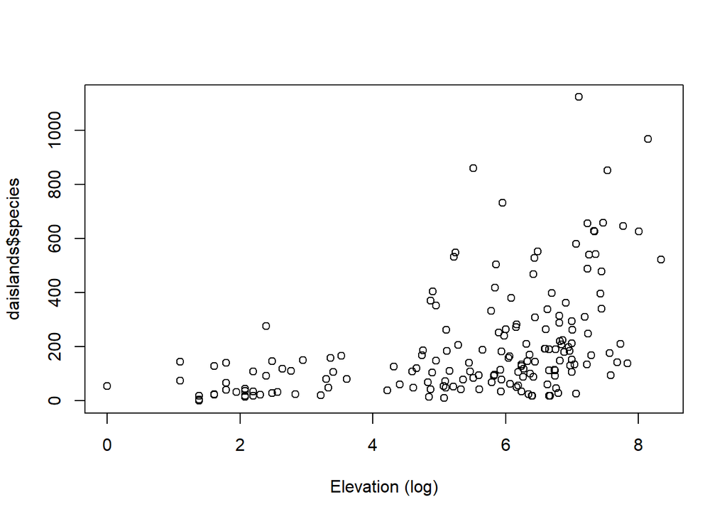

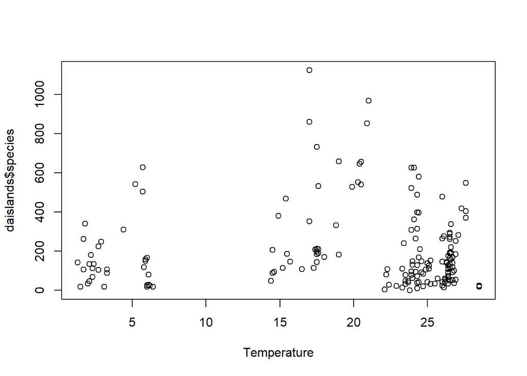

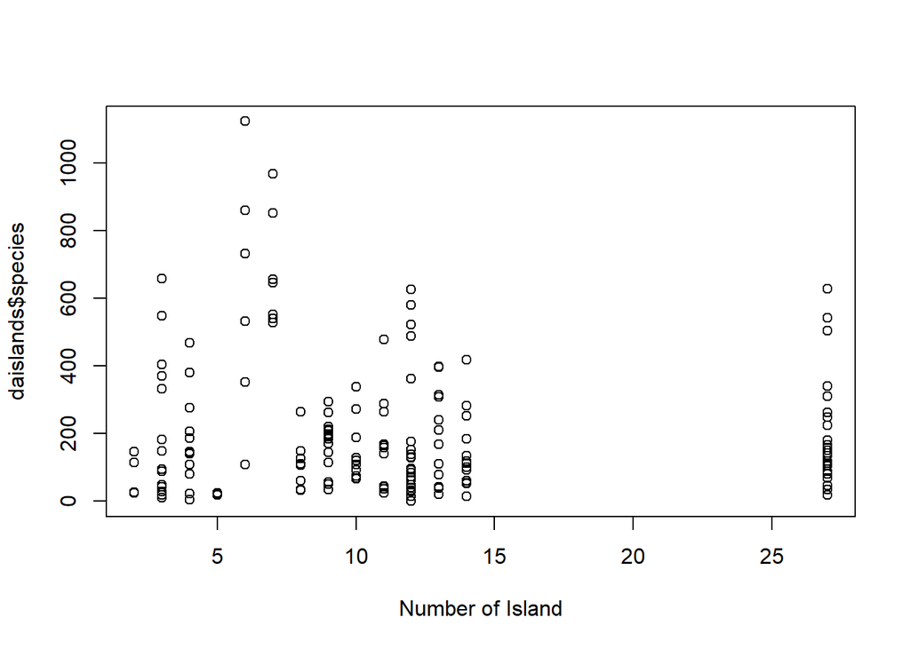

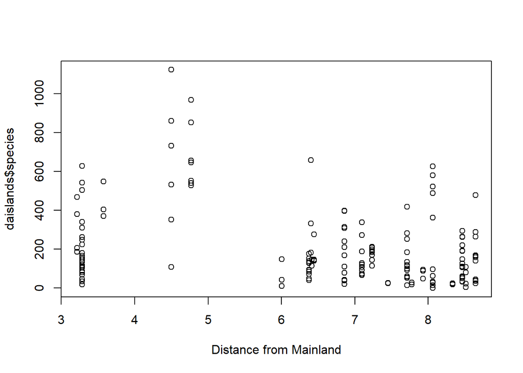

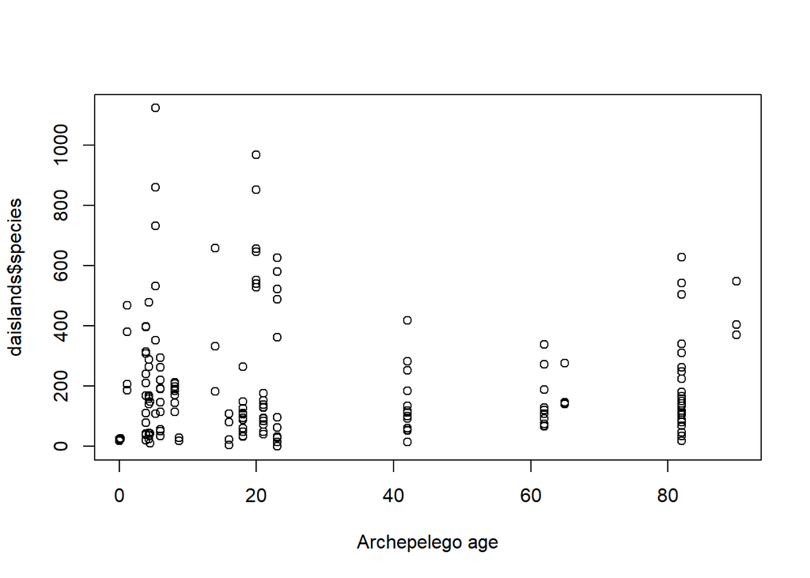

```r
#plot(daislands$archipelago, daislands$species, xlab = "Archipelago")
plot(daislands$area, daislands$species, xlab = "Area (log)")
plot(daislands$elev, daislands$species, xlab = "Elevation (log)")
plot(daislands$temp, daislands$species, xlab = "Temperature")
plot(daislands$island, daislands$species, xlab = "Number of Island")
plot(daislands$distance, daislands$species, xlab = "Distance from Mainland")
plot(daislands$age, daislands$species, xlab = "Archepelego age")
```

# 3 Full model

Make a mixed model that includes all the predictors. Plot fitted effects (fixed and random), plus model diagnostics. How does it look? How much variation do the predictors explain, at the two different scales in the data (island and archipelago)? Present R2 values for the two scales. Also, how much of the total variation have they explained, according to R.

## 3.1 Model Summary

```r
rand.mod = lmer(log(species+1) ~ area + elev + temp + island + distance + age + (1|archipelago), data = daislands)
summary(rand.mod)
```

```
## Linear mixed model fit by REML ['lmerMod']
## Formula: log(species + 1) ~ area + elev + temp + island + distance + age +
##     (1 | archipelago)
##    Data: daislands
##
## REML criterion at convergence: 340
##
## Scaled residuals:
##     Min      1Q  Median      3Q     Max
## -5.6451 -0.4924  0.0620  0.5182  2.0709
##
## Random effects:
##  Groups      Name        Variance Std.Dev.
##  archipelago (Intercept) 0.3757   0.613
##  Residual                0.2591   0.509
## Number of obs: 174, groups:  archipelago, 23
##
## Fixed effects:
##              Estimate Std. Error t value
## (Intercept)  3.119538   0.743024   4.198
## area         0.352814   0.034450  10.241
## elev         0.090439   0.039989   2.262
## temp         0.080771   0.020102   4.018
## island       0.001457   0.026430   0.055
## distance    -0.300267   0.096191  -3.122
## age          0.002992   0.006421   0.466
##
## Correlation of Fixed Effects:
##          (Intr) area   elev   temp   island distnc
## area      0.042
## elev     -0.246 -0.740
## temp     -0.254 -0.197  0.234
## island   -0.208  0.006 -0.033  0.140
## distance -0.730  0.106 -0.042 -0.379 -0.072
## age      -0.366 -0.006  0.068 -0.214 -0.405  0.442
```

```r
# Percent of variance for each model
mod_nopred = lmer(log(species+1) ~ 1 + (1|archipelago), data = daislands)
mod_pred   = lmer(log(species+1) ~ area + elev + temp + island + distance + age + (1|archipelago), data = daislands)

# the archipelego level
1 - VarCorr(mod_pred)$archipelago[1]/VarCorr(mod_nopred)$archipelago[1]
```

```
## [1] 0.4136614
```

```r
# at the island level
1 - (sigma(mod_pred)^2)/(sigma(mod_nopred)^2)
```

```
## [1] 0.6856548
```

```r
# R^2 values
r.squaredGLMM(rand.mod)
```

```
##            R2m      R2c
## [1,] 0.5938215 0.834217
```

## 3.2 Model Diagnostics

```r
plot_model(rand.mod, type = 'diag')[[2]]
```

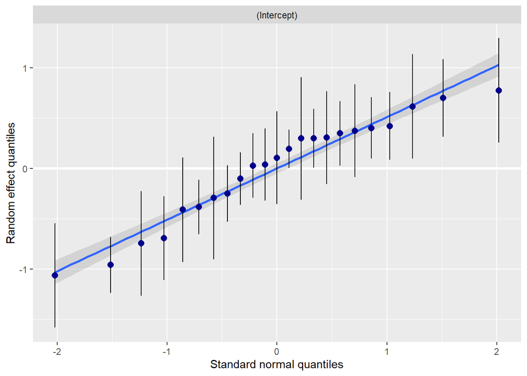

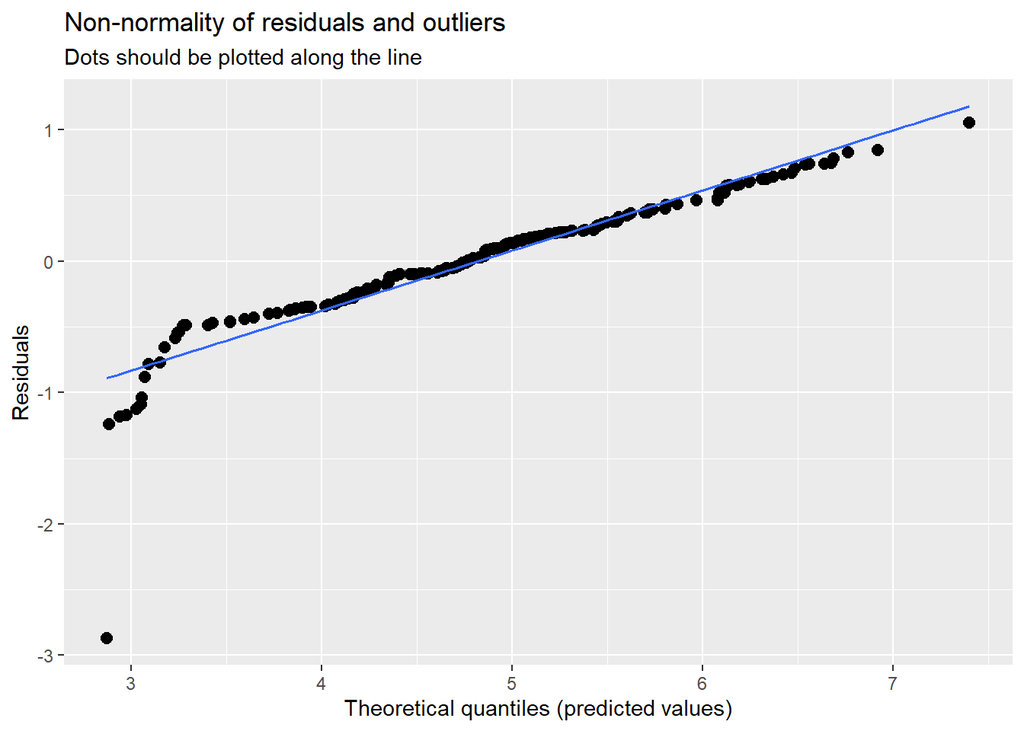

```r
plot_model(rand.mod, type = 'diag')[[1]]
```

## 3.3 Random Effects

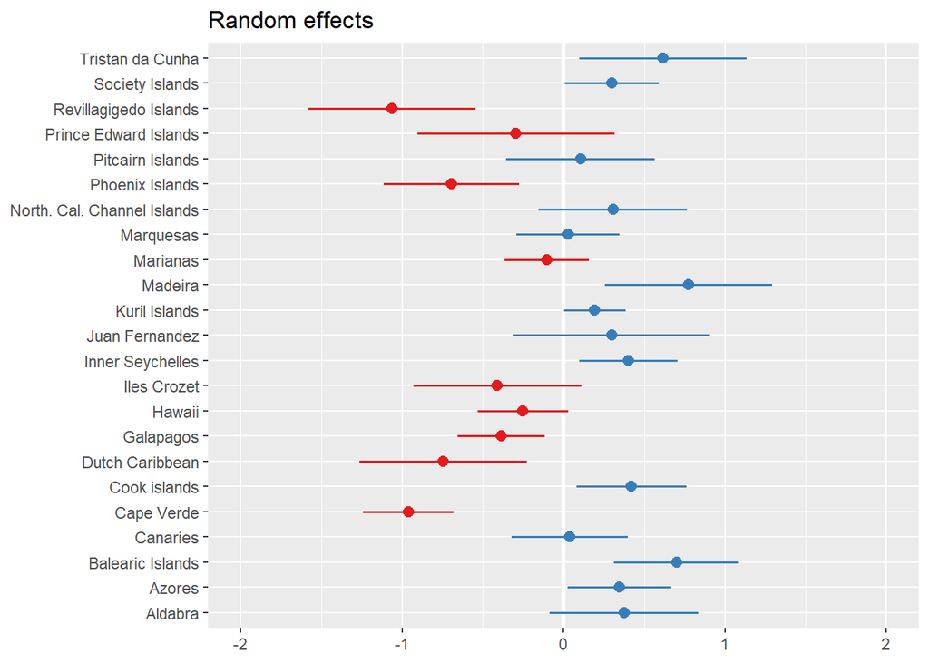

```r
plot_model(rand.mod, type = 're')
```

## 3.4 Fixed Effects

```r
fixef(rand.mod)
```

```
##  (Intercept)         area         elev         temp       island     distance
##  3.119538304  0.352813979  0.090439441  0.080770727  0.001456515 -0.300266597
##          age
##  0.002991891
```

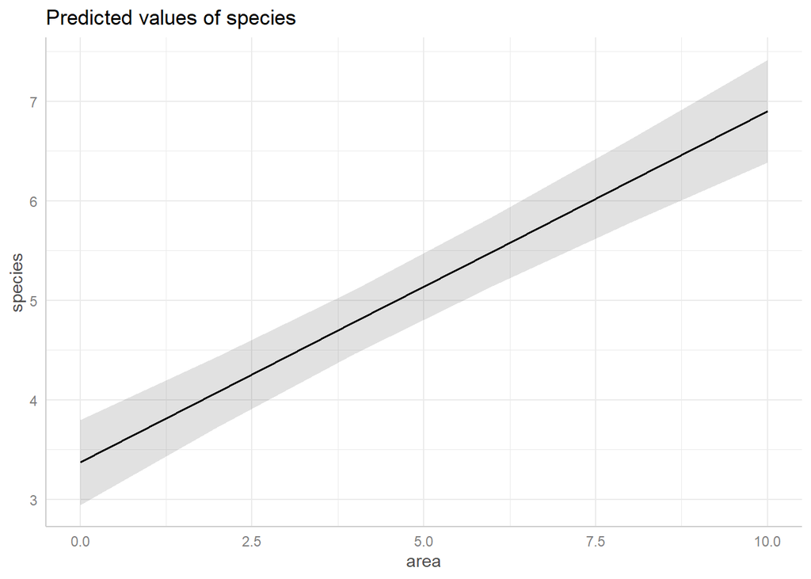

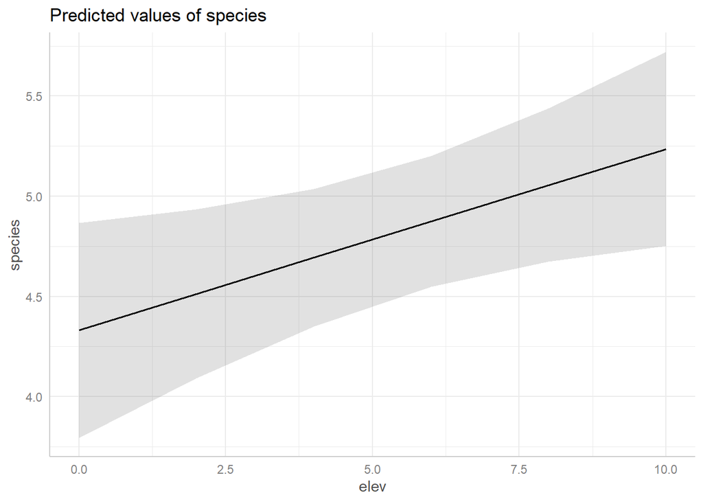

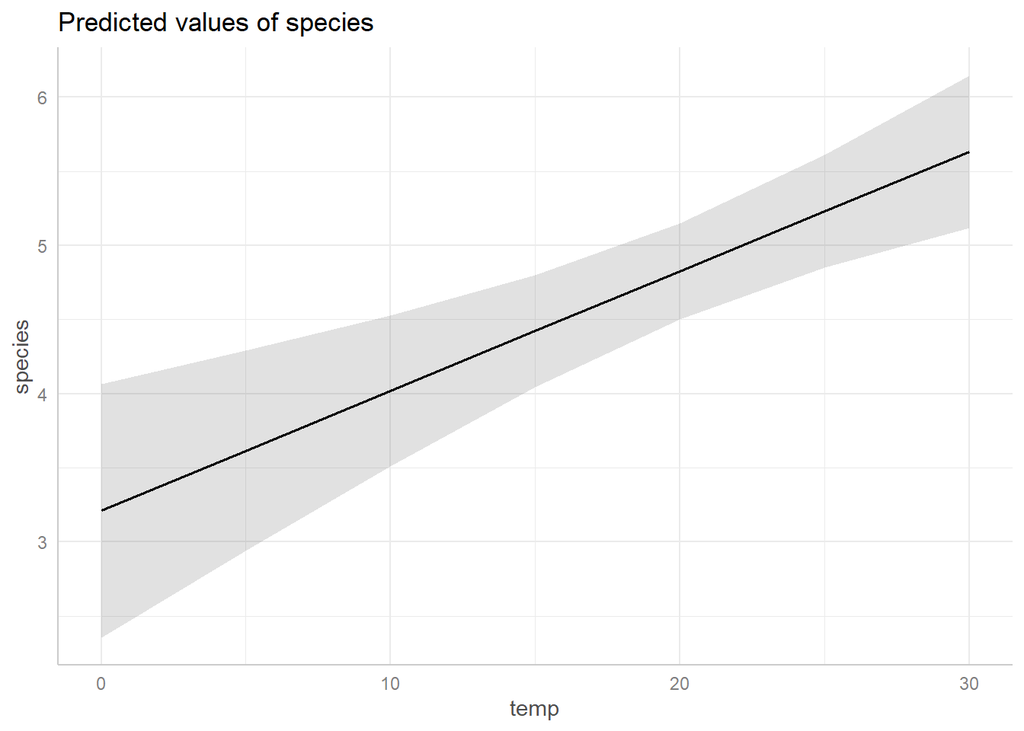

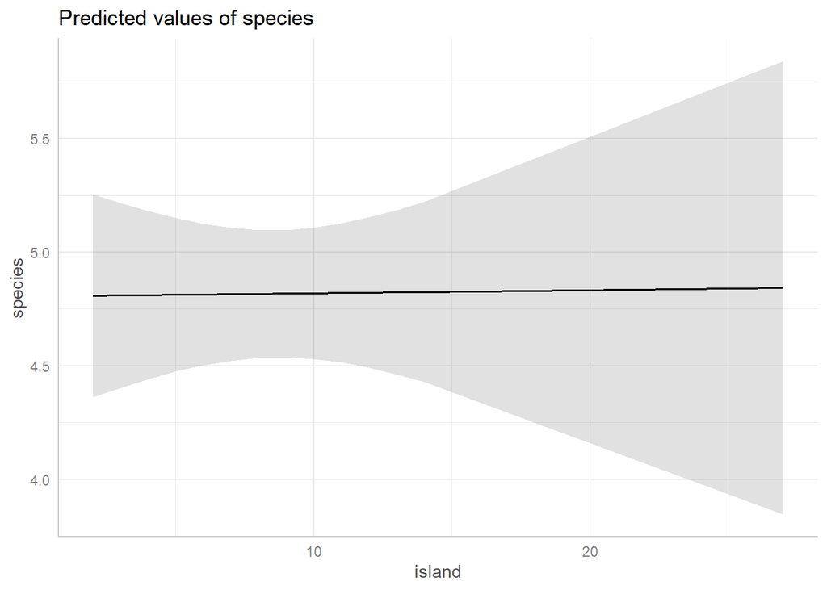

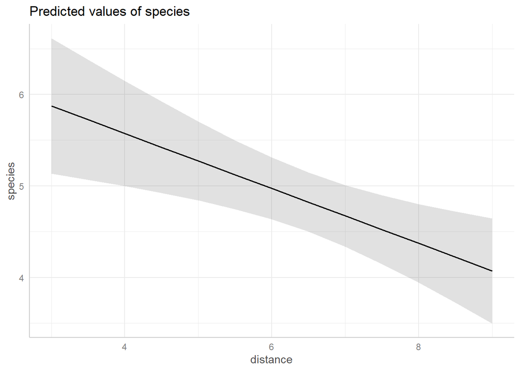

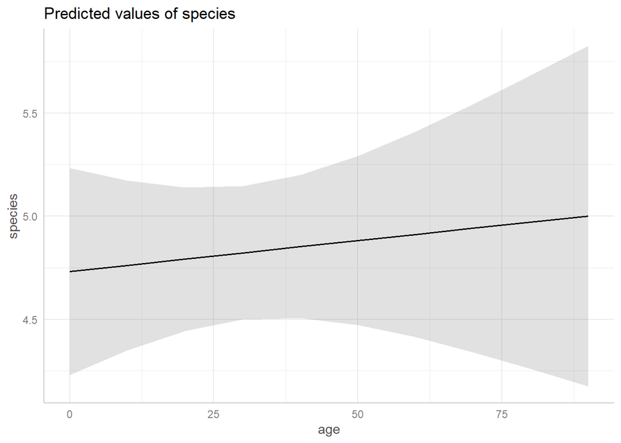

```r
plot(ggeffect(rand.mod))$area
plot(ggeffect(rand.mod))$elev
plot(ggeffect(rand.mod))$temp
plot(ggeffect(rand.mod))$island
plot(ggeffect(rand.mod))$distance
plot(ggeffect(rand.mod))$age

# random.intercepts = ranef(rand.mod)$archipelago[[1]]
#island.type = factor(tapply(daislands$age, daislands$archipelago, function(x) as.character(x[1])))
#fixed.effects.island = fixef(rand.mod)["(Intercept)"] + fixef(rand.mod)["age"]*(island.type == "Azoers")
#island.effects = random.intercepts + fixed.effects.island
#plot(waterbody.effects ~ island.type, col = c('orange', 'grey'), xlab = 'waterbody type', ylab = 'model-fitted intercept')
#curve(island.effects[1] + fixef(epamod)["logTN"]*x, from = min(crysub$logTN),
#      to = max(crysub$logTN), xlab = 'logTN', ylab = 'log density', ylim = c(3.5, 7.5))
#for (i in 2:length(waterbody.effects)) {
# curve(waterbody.effects[i] + fixef(epamod)["logTN"]*x, from = min(crysub$logTN),
#       to = max(crysub$logTN), col = c('orange', 'grey')[waterbody.type[i]], add = T)
#}
```

# 4 Important Predictors

Use approximate F-tests as described in lecture to test the significance of the predictors. How do you interpret the results of these tests, and the effects plots, in light of hypotheses for what controls species richness in islands and archipelagos? What are the denominator degrees of freedom for each predictor? This is essentially telling you how much replication there is for that predictor, minus the number of parameters for that predictor. Do the denominator df make sense? Why or why not?

## 4.1 Anova

```r
null_full   <- lmer(log(species+1) ~ area + elev + temp   + island   + distance + age + (1|archipelago), data = daislands, REML = FALSE)
null_age    <- lmer(log(species+1) ~ area + elev + temp   + island   + distance + (1|archipelago), data = daislands, REML = FALSE) # age missing
null_dist   <- lmer(log(species+1) ~ area + elev + temp   + island   + age + (1|archipelago), data = daislands, REML = FALSE) # distance missing
null_island <- lmer(log(species+1) ~ area + elev + temp   + distance + age + (1|archipelago), data = daislands, REML = FALSE) # island missing
null_temp   <- lmer(log(species+1) ~ area + elev + island + distance + age + (1|archipelago), data = daislands, REML = FALSE) # temp missing
null_elev   <- lmer(log(species+1) ~ area + temp + island + distance + age + (1|archipelago), data = daislands, REML = FALSE) # elev missing
null_area   <- lmer(log(species+1) ~ elev + temp + island + distance + age + (1|archipelago), data = daislands, REML = FALSE) # area missing

mod_full <- lmer(log(species+1) ~ area + elev + temp + island + distance + age + (1|archipelago), data = daislands)
mod_age  <- lmer(log(species+1) ~ area + elev + temp + island + distance + (1|archipelago), data = daislands) # age missing
mod_dist <- lmer(log(species+1) ~ area + elev + temp + island + age + (1|archipelago), data = daislands) # distance missing
mod_island <- lmer(log(species+1) ~ area + elev + temp + distance + age + (1|archipelago), data = daislands) # island missing
mod_temp <- lmer(log(species+1) ~ area + elev + island + distance + age + (1|archipelago), data = daislands) # temp missing
mod_elev <- lmer(log(species+1) ~ area + temp + island + distance + age + (1|archipelago), data = daislands) # elev missing
mod_area <- lmer(log(species+1) ~ elev + temp + island + distance + age + (1|archipelago), data = daislands) # area missing

#sim_null_age = simulate(null_age)
#null.restricted = lmer(sim_null_age[[1]] ~ area + elev + temp + island + distance + (1|archipelago), data = daislands, REML = FALSE)
```

### 4.1.1 Full Model

```r
anova(mod_full, ddf = "Kenward-Roger")
```

```
## Type III Analysis of Variance Table with Kenward-Roger's method
##           Sum Sq Mean Sq NumDF   DenDF  F value    Pr(>F)
## area     26.9551 26.9551     1 159.571 104.0337 < 2.2e-16 ***
## elev      1.3081  1.3081     1 163.380   5.0485 0.0259871 *
## temp      4.0708  4.0708     1  26.597  15.7114 0.0004975 ***
## island    0.0008  0.0008     1  17.566   0.0030 0.9566932
## distance  2.5152  2.5152     1  19.524   9.7076 0.0055600 **
## age       0.0561  0.0561     1  18.751   0.2166 0.6470089
## ---
## Signif. codes:  0 '***' 0.001 '**' 0.01 '*' 0.05 '.' 0.1 ' ' 1
```

### 4.1.2 Area

```r
anova(mod_full, mod_area, ddf = "Kenward-Roger")
```

```
## refitting model(s) with ML (instead of REML)
```

```
## Data: daislands
## Models:
## mod_area: log(species + 1) ~ elev + temp + island + distance + age + (1 | archipelago)
## mod_full: log(species + 1) ~ area + elev + temp + island + distance + age + (1 | archipelago)
##          npar    AIC    BIC  logLik deviance  Chisq Df Pr(>Chisq)
## mod_area    8 400.68 425.95 -192.34   384.68
## mod_full    9 321.67 350.10 -151.83   303.67 81.011  1  < 2.2e-16 ***
## ---
## Signif. codes:  0 '***' 0.001 '**' 0.01 '*' 0.05 '.' 0.1 ' ' 1
```

### 4.1.3 Island

```r
anova(mod_full, mod_island, ddf = "Kenward-Roger")
```

```
## refitting model(s) with ML (instead of REML)
```

```
## Data: daislands
## Models:
## mod_island: log(species + 1) ~ area + elev + temp + distance + age + (1 | archipelago)
## mod_full: log(species + 1) ~ area + elev + temp + island + distance + age + (1 | archipelago)
##            npar    AIC    BIC  logLik deviance Chisq Df Pr(>Chisq)
## mod_island    8 319.67 344.94 -151.83   303.67
## mod_full      9 321.67 350.10 -151.83   303.67     0  1     0.9959
```

### 4.1.4 Distance

```r
anova(mod_full, mod_dist, ddf = "Kenward-Roger")
```

```
## refitting model(s) with ML (instead of REML)
```

```
## Data: daislands
## Models:
## mod_dist: log(species + 1) ~ area + elev + temp + island + age + (1 | archipelago)
## mod_full: log(species + 1) ~ area + elev + temp + island + distance + age + (1 | archipelago)
##          npar    AIC    BIC  logLik deviance  Chisq Df Pr(>Chisq)
## mod_dist    8 330.02 355.29 -157.01   314.02
## mod_full    9 321.67 350.10 -151.83   303.67 10.357  1    0.00129 **
## ---
## Signif. codes:  0 '***' 0.001 '**' 0.01 '*' 0.05 '.' 0.1 ' ' 1
```

### 4.1.5 Temperature

```r
anova(mod_full, mod_temp, ddf = "Kenward-Roger")
```

```
## refitting model(s) with ML (instead of REML)
```

```
## Data: daislands
## Models:
## mod_temp: log(species + 1) ~ area + elev + island + distance + age + (1 | archipelago)
## mod_full: log(species + 1) ~ area + elev + temp + island + distance + age + (1 | archipelago)
##          npar    AIC    BIC  logLik deviance  Chisq Df Pr(>Chisq)
## mod_temp    8 336.31 361.58 -160.16   320.31
## mod_full    9 321.67 350.10 -151.83   303.67 16.645  1  4.506e-05 ***
## ---
## Signif. codes:  0 '***' 0.001 '**' 0.01 '*' 0.05 '.' 0.1 ' ' 1
```

### 4.1.6 Age

```r
anova(mod_full, mod_age, ddf = "Kenward-Roger")
```

```
## refitting model(s) with ML (instead of REML)
```

```
## Data: daislands
## Models:
## mod_age: log(species + 1) ~ area + elev + temp + island + distance + (1 | archipelago)
## mod_full: log(species + 1) ~ area + elev + temp + island + distance + age + (1 | archipelago)
##          npar    AIC   BIC  logLik deviance  Chisq Df Pr(>Chisq)
## mod_age     8 320.03 345.3 -152.01   304.03
## mod_full    9 321.67 350.1 -151.83   303.67 0.3646  1      0.546
```

### 4.1.7 Elevation

```r
anova(mod_full, mod_elev, ddf = "Kenward-Roger")
```

```
## refitting model(s) with ML (instead of REML)
```

```
## Data: daislands
## Models:
## mod_elev: log(species + 1) ~ area + temp + island + distance + age + (1 | archipelago)
## mod_full: log(species + 1) ~ area + elev + temp + island + distance + age + (1 | archipelago)
##          npar    AIC    BIC  logLik deviance  Chisq Df Pr(>Chisq)
## mod_elev    8 324.84 350.12 -154.42   308.84
## mod_full    9 321.67 350.10 -151.83   303.67 5.1787  1    0.02286 *
## ---
## Signif. codes:  0 '***' 0.001 '**' 0.01 '*' 0.05 '.' 0.1 ' ' 1
```

### 4.1.8 Area

```r
anova(mod_full, mod_area, ddf = "Kenward-Roger")
```

```
## refitting model(s) with ML (instead of REML)
```

```
## Data: daislands
## Models:
## mod_area: log(species + 1) ~ elev + temp + island + distance + age + (1 | archipelago)
## mod_full: log(species + 1) ~ area + elev + temp + island + distance + age + (1 | archipelago)
##          npar    AIC    BIC  logLik deviance  Chisq Df Pr(>Chisq)
## mod_area    8 400.68 425.95 -192.34   384.68
## mod_full    9 321.67 350.10 -151.83   303.67 81.011  1  < 2.2e-16 ***
## ---
## Signif. codes:  0 '***' 0.001 '**' 0.01 '*' 0.05 '.' 0.1 ' ' 1
```

## 4.2 R2

```r
mod_nopred = lmer(log(species+1) ~ 1 + (1|archipelago), data = daislands)
mod_pred   = lmer(log(species+1) ~ area + elev + temp + island + distance + age + (1|archipelago), data = daislands)

# the archipelego level
1 - VarCorr(mod_pred)$archipelago[1]/VarCorr(mod_nopred)$archipelago[1]
```

```
## [1] 0.4136614
```

```r
# at the island level
1 - (sigma(mod_pred)^2)/(sigma(mod_nopred)^2)
```

```
## [1] 0.6856548
```

```r
full_r <- r.squaredGLMM(mod_full) # full model
area_r <- r.squaredGLMM(mod_area) # area missin
elev_r <- r.squaredGLMM(mod_elev) # elevation missing
temp_r <- r.squaredGLMM(mod_temp) # temp mising
island_r <- r.squaredGLMM(mod_island) # island missing
dist_r <- r.squaredGLMM(mod_dist) # dist missing
age_r  <- r.squaredGLMM(mod_age) # age missing

df <- data.frame(
  c("full", "age", "dist", "island", "temp", "elev", "area"),
  rbind(full_r, age_r, dist_r, island_r, temp_r, elev_r, area_r))
colnames(df) = c("predictor", "R2m", "R2c")
df
```

```
##   predictor       R2m       R2c
## 1      full 0.5938215 0.8342170
## 2       age 0.6039182 0.8351036
## 3      dist 0.4832140 0.8321485
## 4    island 0.6027037 0.8306282
## 5      temp 0.5459370 0.8366140
## 6      elev 0.5830261 0.8277746
## 7      area 0.4909469 0.7157014
```

## 4.3 Bootstraping

### 4.3.1 Age

```r
PBmodcomp(mod_full, mod_age)
```

```
## Bootstrap test; time: 14.70 sec; samples: 1000; extremes: 768;
## large : log(species + 1) ~ area + elev + temp + island + distance + age +
##     (1 | archipelago)
## log(species + 1) ~ area + elev + temp + island + distance + (1 |
##     archipelago)
##          stat df p.value
## LRT    0.1215  1  0.7274
## PBtest 0.1215     0.7682
```

### 4.3.2 Elevation

```r
PBmodcomp(mod_full, mod_elev)
```

```
## Bootstrap test; time: 14.47 sec; samples: 1000; extremes: 31;
## large : log(species + 1) ~ area + elev + temp + island + distance + age +
##     (1 | archipelago)
## log(species + 1) ~ area + temp + island + distance + age + (1 |
##     archipelago)
##          stat df p.value
## LRT    5.1715  1 0.02296 *
## PBtest 5.1715    0.03197 *
## ---
## Signif. codes:  0 '***' 0.001 '**' 0.01 '*' 0.05 '.' 0.1 ' ' 1
```

### 4.3.3 Temperature

```r
PBmodcomp(mod_full, mod_temp)
```

```
## Bootstrap test; time: 14.35 sec; samples: 1000; extremes: 0;
## large : log(species + 1) ~ area + elev + temp + island + distance + age +
##     (1 | archipelago)
## log(species + 1) ~ area + elev + island + distance + age + (1 |
##     archipelago)
##          stat df   p.value
## LRT    16.414  1 5.091e-05 ***
## PBtest 16.414     0.000999 ***
## ---
## Signif. codes:  0 '***' 0.001 '**' 0.01 '*' 0.05 '.' 0.1 ' ' 1
```

### 4.3.4 Distance

```r
PBmodcomp(mod_full, mod_dist)
```

```
## Bootstrap test; time: 14.22 sec; samples: 1000; extremes: 8;
## large : log(species + 1) ~ area + elev + temp + island + distance + age +
##     (1 | archipelago)
## log(species + 1) ~ area + elev + temp + island + age + (1 | archipelago)
##          stat df  p.value
## LRT    10.118  1 0.001469 **
## PBtest 10.118    0.008991 **
## ---
## Signif. codes:  0 '***' 0.001 '**' 0.01 '*' 0.05 '.' 0.1 ' ' 1
```

### 4.3.5 Island

```r
PBmodcomp(mod_full, mod_island)
```

```
## Bootstrap test; time: 14.19 sec; samples: 1000; extremes: 1000;
## large : log(species + 1) ~ area + elev + temp + island + distance + age +
##     (1 | archipelago)
## log(species + 1) ~ area + elev + temp + distance + age + (1 |
##     archipelago)
##           stat df p.value
## LRT    -0.2429  1       1
## PBtest -0.2429          1
```

### 4.3.6 Area

```r
PBmodcomp(mod_full, mod_area)
```

```
## Bootstrap test; time: 14.19 sec; samples: 1000; extremes: 0;
## large : log(species + 1) ~ area + elev + temp + island + distance + age +
##     (1 | archipelago)
## log(species + 1) ~ elev + temp + island + distance + age + (1 |
##     archipelago)
##          stat df   p.value
## LRT    81.131  1 < 2.2e-16 ***
## PBtest 81.131     0.000999 ***
## ---
## Signif. codes:  0 '***' 0.001 '**' 0.01 '*' 0.05 '.' 0.1 ' ' 1
```

# 5 Using AICc

Is the model we’ve used the best model? Often I just stick with one big model when the ratio of data to parameters is pretty good. But some people really like to find the best model, or to look at model weights, etc. Use AICc in some capacity to assess which predictors are important, what the ‘best’ model is, and how sure you are about what the best model is. The details of how you do it are up to you, as long as it seems justifiable. Remember to do REML=FALSE for comparing models.

## 5.1 Using AICc

```r
df <- data.frame(c("full", "age", "dist", "island", "temp", "elev", "area"),
           c(AICc(mod_full), AICc(mod_age), AICc(mod_dist), AICc(mod_island),
             AICc(mod_temp), AICc(mod_elev), AICc(mod_area)))
colnames(df) <- c("predictor", "AICc")
df
```

```
##   predictor     AICc
## 1      full 358.0439
## 2       age 347.9942
## 3      dist 361.9385
## 4    island 350.5850
## 5      temp 365.3049
## 6      elev 356.5065
## 7      area 431.6175
```